# Моделиране на сложни системи

Докторант: Милена Пирянкова (№ 849/21.03.2018)

Катедра: Управление

Научен ръководител: доц. д-р Ангел Марчев

Създаването на добър модел е важна стъпка към разрешаването на сложни процеси и проблеми. Основната задача на всеки модел е да трансформира входните данни в изходни. Успехът на модела зависи от това колко лесно се използва той и колко точно описва или предсказва поведението на реалната система. В практиката някои от етапите на процеса моделиране от части се сливат. Моделите на стопанските системи се изграждат най-често чрез компютърно моделиране. Независимо от особеностите на различните методи за моделиране, изграждането на модел протича през следните основни фази: дефиниране на концептуален модел, проектиране на компютърен модел, уточняване на адекватността му, реализация на експеримент и анализ на резултатите.

Статистическото моделиране се извършва въз основата на статистиката, теорията на вероятностите и корелационно-регресионния анализ. С времето моделите стават все по-сложни и имат за задача да обработят все по-големи бази от данни. Източниците на големи данни предлагат огромен обем от записи, които изискват обработка. Те надвишават капацитета на традиционните статистически средства за изработване на модели. Поради тази причина се прилагат нови техники за извличане на знания от данни (data mining) и прилагане на алгоритми от областта на машинното обучение (machine learning algorithms).

Машинното самообучение (Machine Learning) е дял от компютърните науки и направление в изкуствения интелект. То представлява група от алгоритми, които изграждат приспособяващо се поведение въз основа на различни модели, открити в изследваните данни Машинното самообучение изследва различни алгоритми, от които една система може да се учи и да подобрява дейността си. То често се използва в областта на извличането на знания от данни, тъй като то може да се използва за създаване на сложни модели, които да прогнозират бъдещото действие на дадена система.

Задачите за прогнозиране построяват регресионни модели, класифицират данните и разпознават различни шаблони и закономерности сред тях. Техниките, които решават тези задачи могат да се наричат надзиравани или управлявани (Supervised Data mining), защото в повечето случаи се прави обучение с част от данните и по този начин се показва как да се търсят зависимостите между данните. Прогнозиращи техники са линейна регресия, класификация, невронни мрежи и други.

В настоящия проект ще разгледаме изкуствените невронни мрежи като средство за прогнозиране.

### Изкуствени невронни мрежи

Невронните мрежи са компютърен модел, който възниква в областта на изкуствения интелект преди повече от 50 години в трудовете на Доналд Хеб. Първоначално са възникнали с цел да изучават и имитират нервно физиологичната дейност на човешкия мозък чрез комбинация на елементарни изчислителни елементи в една голяма и сложна система. Днес те са обект на изучаване най-вече в областта на машинното самообучение.

Предимство на невронние мрежи е възможността те да бъдат обучени, а в последствие да се самообучават. Нвронните мрежи предлагат ефективно моделиране на сложни проблеми, при които участват голям брой предсказващи променливи. Те са много популярни, защото имат доказан опит при извличане на знания и решения при изследване на много сложни системи. Тези модели могат да се използват за класификация и клъстеризация, могат да описват данните, но и да решават задачи за предсказване. Изкуствените невронни мрежи се използват в много различни области – прогнозиране на ситуации на фондовите пазари, диагностициране на медицински състояния, идентифициране на измамни с кредитни и дебитни карти и други.

Невронната мрежа представлява комплексната динамична структура която се състои от силно взаимосвързани елементи, наречени неврони. Всеки отделен неврон в невронната мрежа няма “интелигентност” сам по себе си. Функционалността на невронната мрежа се определя главно от връзките между отделните неврони в нея. По този начин поведението на невронната мрежа може да се разглежда като интелигентно.

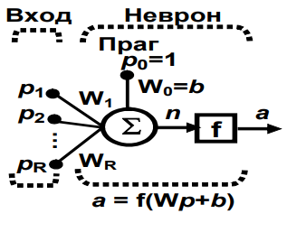

Фиг 1. Схема на неврон

Вход на неврона е вектора $p = [p1, p2, …, pn]$ от изходните сигнали на други неврони. Всяка входна стойност се умножава с съответното тегло $W1, W2, …, Wn$, от вектора $W$, всички произведения се сумират в сумиращия блок $\sum$ - изходът му е $n$, което определя степента на активиране на неврона. Сумата от произведенията на теглата и входовете със праговете е аргумент на трансферната (активираща) функция $f$. Трансферните функции могат да бъдат от различен тип – линейни, нелинейни, диференцируеми и др. Трансферната функция произвежда изхода на неврона който е означен с $a$.

Параметрите на неврона които могат да бъдат обучени са векторите от теглата и праговете, респективно $W$ и $b$. Математическият аналог на биологичната невронна мрежа представлява множество от взаимносвързани прости изчислителни елементи (неврони), като всеки от тях приема сигнали от другите (под формата на числа), сумира ги, като сумата минава през активационна функция (най-често използваната е $y=f(x)=1/(1+\epsilon-х))$, и така определя своята активация (степен на възбуда), която се предава по изходящите връзки към другите неврони. Всяка връзка има тегло, което умножавайки се със сигнала, определя неговата значимост (сила).

Теглата на връзките са аналогични на силата на синаптичните импулси, предавани между биологичните неврони. Отрицателна стойност на теглото съответства на подтискащ импулс, а положителна - на възбуждащ. Невронните мрежи се състоят от един, два или повече отделни слоя, които могат да бъдат организирани в различна топология. Математически е доказано, че невронна мрежа с повече от един слой с достатъчно на брой неврони, може да моделира поведението на всяка съществуваща функция.

Теглата на връзките между невроните определят функционалността и поведението на невронната мрежа. Съществено предимство на невронните архитектури е възможността те да бъдат обучавани, а в последствие и да се самообучават. Обучението на една невронна мрежа се постига чрез промяна на теглата на връзките между невроните и се осъществява чрез правила, които определят как да се променят тези тегла. Най-разпространеното сред тях е методът на обратното разпространение на сигнал за грешка (back-propogation), където за всеки изходен неврон се изчислява разликата от желаното му поведение, като се формира сигнал за грешка, който се движи назад към входния слой и по пътя си променя теглата на връзките така, че при следващата активация на мрежата грешката да бъде по-малка от регистрираната. Веднъж след като мрежата е „обучена“, тя трябва да се „захрани“ с нови данни, които не са били използвани по време на нейното обучение. Това е своеобразен начин на тестване на невронната мрежа, за да се установи дали е в състояние да прогнозира неизвестните изходи или по- точно, способна ли е да генерализира.

Като илюстрация на свързани неврони на фигура по-долу е показана двуслойна невронна мрежа с право разпространение на сигнала (НМПРС). Тя има R входа, S1 неврона в първия слой и S2 неврона в втория слой. Различните слоеве могат да имат различен брой неврони. Изходите на първия слой неврони са входове на втория слой неврони и всеки неврон от първия слой е свързана със всеки неврон от втория слой.

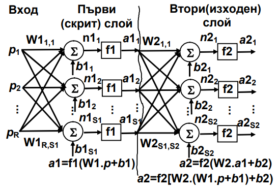

Фиг 2. Схема на невронна мрежа

Възможен проблем при обучението на невронната мрежа е така наречения ефект на “преобучението” при който със обучаващата извадка се минимизира грешката, но при проверка на невронната мрежа със тестови данни се оказва, че грешката се повишава след определен брой итерации.

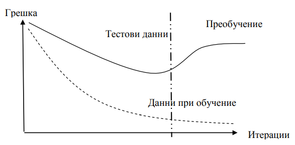

Фиг 3. Преобучаване на невронната мрежа

От съществено значение за обучението на всяка невронна мрежа е това в кой момент да спре нейното обучение. В идеалния случай процесът по обучение е под прякото наблюдение на изследователя и обучението спира тогава, когато качеството започне да се влошава. Но това често е неприложимо на практика и затова е необходимо да се приложи някакво стопиращо условие (stopping condition), с което да се гарантира, че времето за обучение е крайно и че мрежата не е нито преобучена/пренастроена (overtrained/overfitted), нито недостатъчно обучена (undertrained).

Най-често невронните мрежи намират приложение във финансовите дейности. Невроните мрежи са намерили подръжници сред множество напредничави мениджъри на портфейли в инвестиционни банки и инвестиционни посредници. Повечето от инвестиционните банки като Голдман Сакс и Морган Сетенли изграждат цели отдели за разработката и прилагането на невронни мрежи. Фиделити Инвестмънт е основала взаимен фонд чието портофолио се базира главно върху препоръки давани от невронна мрежа. Фактът, че големи компании инвестират ресурси и време в невроните мрежи, показва че невроните мрежи могат да служат като важен метод за предсказване на икономически данни.

### Практическа част

В настоящата разработка ще бъде разгледана невронна мрежа, програмирана на език R.

Целта е да се изгради адекватна прогноза за цена на покупка и цена на продажба на различните криптовалути, отчитайки дълбочината на пазара. Повечето прогнози са изградени на база историческите цени на криптовалутите и дълбочината на пазара често остава неотразена.

Дълбочината на пазара описва електронен списък в реално време на всички поръчки за покупка и продажба, чакащи да бъдат изпълнени. За инвеститорите е полезно да видят къде се намира тежестта на предложенията и офертите за дадена ценна книга.

Първичната емперична база на изследването е разделена на 5 минутни интервали от 2018-06-21 20:00:00 UTC до 2018-08-11 15:25:00 UTC

```
- 14,640 наблюдения като всяко от тях съдържа следната информация:
- 50 различни офертни цени за покупка;
- обем на всички поръчки за покупка на съответната цена;
- брой поръчки за покупка на съответната цена;
- 50 различни офертни цени за продажба;
- обем на всички поръчки за продажба на съответната цена;
- брой поръчки за продажба на съответната цена;
```

В невронната мрежа, която ще бъде разгледана е използвана функция neuralnet

neuralnet(formula, data, hidden = 1, threshold = 0.01, stepmax = 1e+05, rep = 1, startweights = NULL, learningrate.limit = NULL, learningrate.factor = list(minus = 0.5, plus = 1.2), learningrate = NULL, lifesign = "none", lifesign.step = 1000, algorithm = "rprop+", err.fct = "sse", act.fct = "logistic", linear.output = TRUE, exclude = NULL, constant.weights = NULL, likelihood = FALSE)

където:

- formula - математическо описание на модела;
- data - таблица от тип data.frame, която съдържа данните обучаващи модела и съдържащи се в математическото описание;
- hidden - вектор от цели числа, указващ броя на скритите неврони във всеки слой;
- threshold - цифрова стойност, коятоопределя прага за частичните производни на функцията за грешка като критерии за спиране;
- stepmax - максимален брой стъпки за обучение на невронната мрежа, достигането на този максимум води до спиране на процеса на обучение на невронната мрежа;
- rep - брой повторения на обучението на невронната мрежа;
- startweights - числов вектор, който съдържа началните стойности на отделните тегла. Задава се NULL за случайна инициализация;
- learningrate.limit - числов вектор или списък, съдържащ стойности за най-ниската и най-високата граница на степента на обучение на невронната мрежа. Използва се само при алгоритми RPROP и GRPROP;
- learningrate.factor - числов вектор или списък, съдържащ коефициентите за умножение на горната и долната граница за степента на обучение. Използва се само за RPROP и GRPROP;
- learningrate - Цифрова стойност, определяща степента на обучение, използвана при . Използва се само за традиционно разпространение;
- lifesign - символен низ, който определя дали да се отпечатват резултати по време на обучението на невронната мрежа: "none" - не отпечатва нищо, "minimal" - отпечатва част от резултатите, "full" - отпечатва всичко
- lifesign.step - цяло число, което посочва размера на стъпката, през която да се отпечатва резултат от обучението на мрежата
- algorithm - символен низ, който определя типа на алгоритъма за обучение на невронната мрежа. Възможни са следните типове: "backprop", "rprop +", "rprop-", "sag" или "slr". „backprop“ се отнася за мрежа с обратното разпространение на сигнала, „rprop +“ и „rprop-“ се отнасят до еластичното обратно разпространение на сигнала със и без обратно връщане на теглото, докато „sag“ и „slr“ са модифицирани конвергентни алгоритъми (grprop);
- err.fct - функция, която се използва за изчисляване на грешката. Могат да се използват низовете „sse“ и „ce“, които представляват сумата от квадратните грешки (sum of square errors) и кръстосаната ентропия (cross-entropy).
- act.fct - функция, която се използва за изглаждане на теглата. За логистичната функция и допирателната хиперболика са възможни низове "logistic" и "tanh";
- linear.output - Ако act.fct не трябва да се прилага към изходните неврони, то трябва да се зададе TRUE, в противен случай трябва да се избере стойност FALSE;
- exclude - вектор или матрица, определящи теглата, които са изключени от обучението. Ако е даден като вектор, точните позиции на тежестите трябва да бъдат известни. Матрица с n-редове и 3 колони ще изключи n тегла, където първата колона означава слоя, втората колона за входния неврон и третата колона за изходния неврон на теглото.
- constant.weights - вектор, определящ стойностите на теглата, които са изключени от процеса на обучение и се третират като фиксирани;
- likelihood - Ако функцията за грешка е равна на отрицателната функция за логаритмична вероятност, ще бъдат изчислени информационните критерии AIC и BIC.

```r
# ----- инсталиране на пакети -----
install.packages("neuralnet",  repos='http://cran.us.r-project.org')
install.packages("readxl",  repos='http://cran.us.r-project.org')
install.packages("stringr",  repos='http://cran.us.r-project.org')
```

```r
# ----- зареждане на библиотеки -----
library(readxl)
library(neuralnet)
library(data.table)
library(tibble)
```

```r
# ----- зареждане на базата данни -----
all_data <- read_xlsx("milenka_the_great_data_all2.xlsx", sheet =1, col_names = TRUE)
```

```r
# ----- наименуване на всяка колона  -----
ask_number <- (ncol(all_data)%/%2)+1
j<-1; k<-1

# ----- всяка колона съдържаща цени се преименува съответно на: -----
# ----- ask_price_[пореден номер]
# ----- bid_price_[пореден номер]

for (i in seq(2, ncol(all_data), 3))
{
  if (i<=ask_number) {
    colnames(all_data)[i]<- paste0("ask_price_",j)
    j<-j+1
  }else{colnames(all_data)[i]<- paste0("bid_price_",k); k<-k+1}
}

# ----- всяка колона съдържаща обем на поръчката се преименува съответно на:
# ----- ask_volume_[пореден номер]
# ----- bid_volume_[пореден номер]

j<-1; k<-1
for (i in seq(3, ncol(all_data), 3))
{
  if (i<=ask_number) {
    colnames(all_data)[i]<- paste0("ask_volume_",j)
    j<-j+1
  }else{colnames(all_data)[i]<- paste0("bid_volume_",k); k<-k+1}
}

# ----- всяка колона съдържаща обем на поръчката се преименува съответно на:
# ----- ask_num_orders_[пореден номер]
# ----- ask_num_orders_[пореден номер]

j<-1; k<-1
for (i in seq(4, ncol(all_data), 3))
{
  if (i<=ask_number) {
    colnames(all_data)[i]<- paste0("ask_num_orders_",j)
    j<-j+1
  }else{colnames(all_data)[i]<- paste0("bid_num_orders_",k); k<-k+1}
}
```

```r
# ----- закръгляне на данните, отразяващи брой поръчки,
# ----- тъй като има няколко стойности запълнени предварително с линейна интерполация
for (i in seq(4, ncol(all_data), 3)){
  all_data[,i] <- round(all_data[,i])
}
```

След като сме изчели данните и преименували подходящо всяка колона построяваме графики, на които се виждат офертните цени за покупки и продажби ( 5 минутни интервали от 2018-06-21 20:00:00 UTC до 2018-08-11 15:25:00 UTC)

```r
# ----- създаване на нова таблица, съдържаща само колоните с цени: ask_price_[пореден номер] и bid_price_[пореден номер]

all_prices <- list()
j<-1
for (i in seq(2, ncol(all_data), 3)){
  all_prices[j] <- all_data[,i]
  j=j+1
}

all_prices <- as.data.frame(all_prices)
for (i in 1:ncol(all_prices)) {
  if (i<51) {
    colnames(all_prices)[i]<- paste0("ask_price_",i)
  }else {colnames(all_prices)[i]<- paste0("bid_price_",i-50)}
}
```

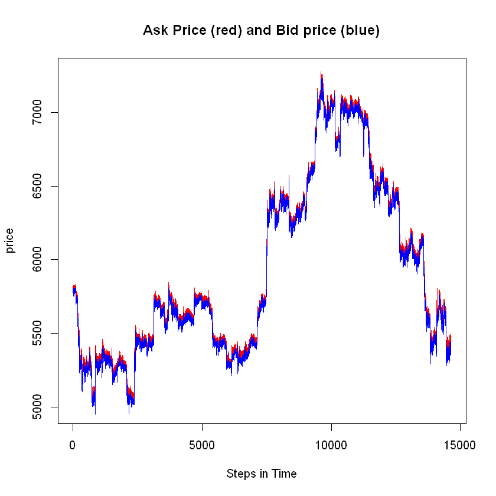

```r
# ----- Графика на всички цени от базата данни ( за целия период ) -----

matplot(all_prices[,1:50], xlab="Steps in Time",ylab="price",type = c("l"), col="red", main = "Ask Price (red) and Bid price (blue)")
matlines(all_prices[,51:100], type = c("l"), col="blue")
```

- Цена "Купува" (Bid price) представлява най-високата поръчка за покупка, която в момента съществува на пазара, т.е. най-високата цена, която някой инвеститор е готов да заплати за откриване на дълга позиция.
- Цена "Продава" (Ask price) представлява най-ниската поръчка за продажба, която в момента съществува на пазара (т.е. най-ниската цена, която някой инвеститор е готов да заплати за откриване на къса позиция).

На графиката се вижда известна разлика между дврете цени: Bid price са под Ask Price, защото инвеститорите искат да купят на възможно най-ниската пазарна цена и да продадат на възможно най-високата такава.

Следващите графики представялват поглед на част от всички данни, за да се придобие по-добра представа за разликата между цена "купува" и цена "продава". На първата графика са изчертани първите 700 наблюдения, а на втората - първите 50 наблюдения.

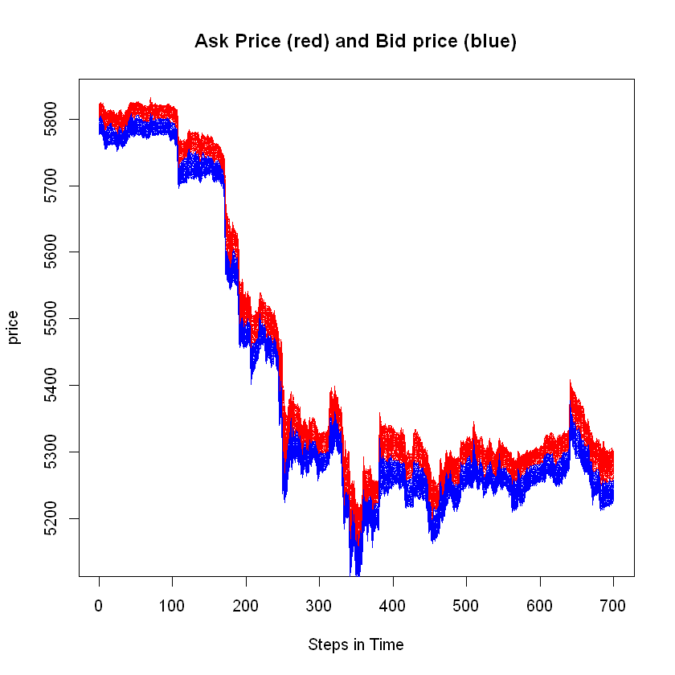

```r
# ----- графика на първите 700 наблюдения -----

matplot(all_prices[1:700,1:50], xlab="Steps in Time",ylab="price",type = c("l"), col="red", main = "Ask Price (red) and Bid price (blue)")
matlines(all_prices[1:700,51:100], type = c("l"), col="blue")
```

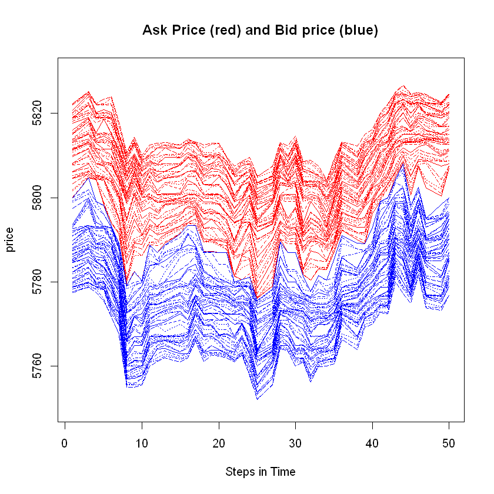

```r
# ----- графика на първите 50 наблюдения -----

matplot( all_prices[1:50,1:50], xlab="Steps in Time",ylab="price",ylim=c(5750,5830),type = c("l"), col="red", main = "Ask Price (red) and Bid price (blue)")
matlines(all_prices[1:50,51:100], type = c("l"), col="blue")
```

Последната графика показва данни за първите 50 периода. Много ясно се виждат линиите на всички поръчки за покупка (в син цвят) и продажба (в червен цвят), чакащи да бъдат изпълнени.

Целта на невронната мрежа, която ще бъде построена по-долу е да направи две прогнози едновременно:

- прогноза за следващата цена "купува"
- прогноза за следващата цена "продава"

```r
# ----- създаване на две нови работни колони, едната съдържа всички цени покупка, другата съдържа всички цени продажба -----
ask_prices<-all_prices[,1:50]
bid_prices<- all_prices[,51:100]
```

Тъй като ни трябва прогноза с един такт напред, ще изместим двете най-близки цени от цени "Покупка" и цени "Продажба" с един такт. Тях ще използваме като зависимата променлива, която искаме да прогнозираме по-нататък с невронната мрежа. Тоест нашата цел е използвайки всички цени "купува" и цени "продава" през период t да направим едновременно прогноза за:

- най-близката цена "Купува" до цена "Продава" за период t+1
- най-близката цена "Продава" до цена "Купува" за период t+1

```r
# ----- създаване на колонка за най-близката цена "Купува" до цена "Продава" за период t+1 -----
# ----- трием последният ред от данните, защото ще бъде запълнен с NA -----
ask50t1 <- shift(ask_prices$ask_price_50, n=1, type = "lead")
ask_prices <- add_column(ask_prices, ask50t1=ask50t1)
ask_prices <- ask_prices[-14640,]
```

```r
# ----- създаване на колонка за най-близката цена "Продава" до цена "Купува" за период t+1 -----
# ----- трием последният ред от данните, защото ще бъде запълнен с NA -----
bid1t1 <- shift(bid_prices$bid_price_1, n=1, type = "lead")
bid_prices <- add_column(bid_prices, bid1t1=bid1t1)
bid_prices <- bid_prices[-14640,]
```

Разделяме данните на обучаваща и тестова последователност

```r
# ----- Разделяме данните на обучаваща и тестова последователност данните за цена продава -----

train_data_ask <- ask_prices[1:round((nrow(ask_prices)/2)),]
test_number <- round((nrow(ask_prices)/2))+1
test_data_ask <- ask_prices[test_number:nrow(ask_prices),]
```

```r
# ----- Разделяме данните на обучаваща и тестова последователност данните за цена купува -----

train_data_bid <- bid_prices[1:round((nrow(bid_prices)/2)),]
test_number <- round((nrow(bid_prices)/2))+1
test_data_bid <- bid_prices[test_number:nrow(bid_prices),]
```

```r
# ----- С цел по-прецизна работа на невронната мрежа трябва да нормализираме данните -----
# ----- Нормализиране на данните за цена продава -----

min_train_ask <- apply(train_data_ask,2,min)
max_train_ask <- apply(train_data_ask,2,max)

min_test_ask <- apply(test_data_ask,2,min)
max_test_ask <- apply(test_data_ask,2,max)

norm_train_ask <- (train_data_ask - min_train_ask)/(max_train_ask-min_train_ask)
norm_test_ask <- (test_data_ask - min_test_ask)/(max_test_ask-min_test_ask)

# ----- Нормализиране на данните за цена купува -----

min_train_bid <- apply(train_data_bid,2,min)
max_train_bid <- apply(train_data_bid,2,max)

min_test_bid <- apply(test_data_bid,2,min)
max_test_bid <- apply(test_data_bid,2,max)

norm_train_bid <- (train_data_bid - min_train_bid)/(max_train_bid-min_train_bid)
norm_test_bid <- (test_data_bid - min_test_bid)/(max_test_bid-min_test_bid)
```

```r
# ----- обединяване на нормализираните цени за купува и продава в две нови работни таблици -----
# ----- едната таблица съдържа данните от обучаващата последователност -----
# ----- втората таблица съдържа данните от тестовата последователност -----

norm_train_all <-cbind(norm_train_ask,norm_train_bid)
norm_test_all <- cbind(norm_test_ask,norm_test_bid)
```

Както по-горе видяхме, за да използваме фунцкията neuralnet трябва да имаме предварително дефинирана формула, която да посочим вътре. За тази цел дефинираме нашата формула. От лявата страна трябва да останат двете зависими променливи ( цена "купува" и цена "продава" за период t+1), а от дясната всички останали за период t.

$ \begin{aligned} \large F= {ask.price_n}_{t+1} + {bid.price_1}_{t+1} \sim {ask.price_1}_{t} + {ask.price_2}_{t}+...+{ask.price_n}_{t}+{bid.price_1}_{t}+{bid.price_2}_{t}+...+{bid.price_n}_{t} \end{aligned} $

където:

- $n$ - пореден номер на офертна цена
- ${ask.price_n}_{t}$ - Цена "Продава", която се намира най-близо до цена "Купува" за текущия период
- ${ask.price_n}_{t+1}$ - Цена "Продава", която се намира най-близо до цена "Купува" за следващия период
- ${bid.price_1}_{t}$ - Цена "Купува", която се намира най-близо до цена "Продава" за текущия период
- ${bid.price_1}_{t+1}$ - Цена "Купува", която се намира най-близо до цена "Продава" за следващия период

```r
# ----- създаване на формула, която ще се използва в невронната мрежа по-долу

allVars <- colnames(norm_train_all) #
predictorValues <- allVars[!allVars%in%"ask50t1"]  #
predictorValues <- predictorValues[!predictorValues%in%"bid1t1"]
predictorValues <- paste(predictorValues, collapse="+")
form <- as.formula(paste("ask50t1+bid1t1~", predictorValues, collapse = "+"))
form
```

```
ask50t1 + bid1t1 ~ ask_price_1 + ask_price_2 + ask_price_3 +
    ask_price_4 + ask_price_5 + ask_price_6 + ask_price_7 + ask_price_8 +
    ask_price_9 + ask_price_10 + ask_price_11 + ask_price_12 +
    ask_price_13 + ask_price_14 + ask_price_15 + ask_price_16 +
    ask_price_17 + ask_price_18 + ask_price_19 + ask_price_20 +
    ask_price_21 + ask_price_22 + ask_price_23 + ask_price_24 +
    ask_price_25 + ask_price_26 + ask_price_27 + ask_price_28 +
    ask_price_29 + ask_price_30 + ask_price_31 + ask_price_32 +
    ask_price_33 + ask_price_34 + ask_price_35 + ask_price_36 +
    ask_price_37 + ask_price_38 + ask_price_39 + ask_price_40 +
    ask_price_41 + ask_price_42 + ask_price_43 + ask_price_44 +
    ask_price_45 + ask_price_46 + ask_price_47 + ask_price_48 +
    ask_price_49 + ask_price_50 + bid_price_1 + bid_price_2 +
    bid_price_3 + bid_price_4 + bid_price_5 + bid_price_6 + bid_price_7 +
    bid_price_8 + bid_price_9 + bid_price_10 + bid_price_11 +
    bid_price_12 + bid_price_13 + bid_price_14 + bid_price_15 +
    bid_price_16 + bid_price_17 + bid_price_18 + bid_price_19 +
    bid_price_20 + bid_price_21 + bid_price_22 + bid_price_23 +
    bid_price_24 + bid_price_25 + bid_price_26 + bid_price_27 +
    bid_price_28 + bid_price_29 + bid_price_30 + bid_price_31 +
    bid_price_32 + bid_price_33 + bid_price_34 + bid_price_35 +
    bid_price_36 + bid_price_37 + bid_price_38 + bid_price_39 +
    bid_price_40 + bid_price_41 + bid_price_42 + bid_price_43 +
    bid_price_44 + bid_price_45 + bid_price_46 + bid_price_47 +
    bid_price_48 + bid_price_49 + bid_price_50
```

Създаване на невронна мрежа с 2 скрити слоя - първият съдържа 4 неврона, вторият 2 неврона.

```r
neuralModel <- neuralnet(formula = form, hidden = c(4,2), linear.output = T, data = norm_train_all, stepmax = 300000)
```

Време за обучение - приблизително 35 минути.

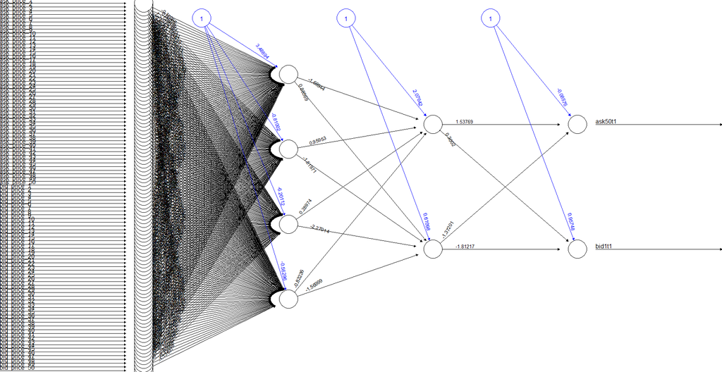

```r
plot(neuralModel)
```

След като вече имаме готов модел следва да се пусне с тестовите данни

```r
# ----- използване на обучената невронна с тестовите данни -----

predictions_all <- compute(neuralModel, norm_test_all)
str(predictions_all)
```

```
List of 2
 $ neurons   :List of 3
  ..$ : num [1:7319, 1:101] 1 1 1 1 1 1 1 1 1 1 ...
  .. ..- attr(*, "dimnames")=List of 2
  .. .. ..$ : chr [1:7319] "7321" "7322" "7323" "7324" ...
  .. .. ..$ : chr [1:101] "" "ask_price_1" "ask_price_2" "ask_price_3" ...
  ..$ : num [1:7319, 1:5] 1 1 1 1 1 1 1 1 1 1 ...
  .. ..- attr(*, "dimnames")=List of 2
  .. .. ..$ : chr [1:7319] "7321" "7322" "7323" "7324" ...
  .. .. ..$ : NULL
  ..$ : num [1:7319, 1:3] 1 1 1 1 1 1 1 1 1 1 ...
  .. ..- attr(*, "dimnames")=List of 2
  .. .. ..$ : chr [1:7319] "7321" "7322" "7323" "7324" ...
  .. .. ..$ : NULL
 $ net.result: num [1:7319, 1:2] 0.195 0.197 0.19 0.187 0.2 ...
  ..- attr(*, "dimnames")=List of 2
  .. ..$ : chr [1:7319] "7321" "7322" "7323" "7324" ...
  .. ..$ : NULL
```

```r
# ----- Денормализиране на получените резултати -----

pred_all<- predictions_all$net.result

pred_ask <- pred_all[,1]
pred_bid <- pred_all[,2]

denorm_pred_ask<-pred_ask*(max_test_ask[51]-min_test_ask[51])+min_test_ask[51]
denorm_pred_bid<-pred_bid*(max_test_bid[1]-min_test_bid[1])+min_test_bid[1]
```

```r
# ----- Изчисляване на Mean Square Error (средна квадратична грешка) за двете цени - купува и продава -----
MSE_ask <- sum((test_data_ask$ask50t1-denorm_pred_ask)^2)/nrow(test_data_ask)
MSE_bid <- sum((test_data_bid$bid1t1-denorm_pred_bid)^2)/nrow(test_data_bid)
```

```r
# ----- създаване на нови таблици, която съдържа прогнозираните данни и реалните данни -----

# ask
final_ask <- (test_data_ask$ask50t1-denorm_pred_ask)
result_ask <- (test_data_ask$ask50t1+final_ask)
forecast_result_ask<-as.data.frame(cbind(result_ask,test_data_ask$ask50t1 ))
colnames(forecast_result_ask)<- c("forecast_ask", "actual_ask")

#bid

final_bid <- (test_data_bid$bid1t1-denorm_pred_bid)
result_bid <- (test_data_bid$bid1t1+final_bid)
forecast_result_bid<-as.data.frame(cbind(result_bid,test_data_bid$bid1t1 ))
colnames(forecast_result_bid)<- c("forecast_bid", "actual_bid")
```

Резултати и графика от прогнозата за цена "продава"

```r
# ----- първите 5 наблюдения от тестовата последователност за цена "Продава": сравнение между прогноза и реални данни -----
head(forecast_result_ask)
```

|  | forecast_ask | actual_ask |
| --- | --- | --- |
| 7321 | 5768.388 | 5756.50 |
| 7322 | 5767.150 | 5757.75 |
| 7323 | 5784.104 | 5759.23 |
| 7324 | 5789.097 | 5759.57 |
| 7325 | 5766.368 | 5760.00 |
| 7326 | 5753.805 | 5760.79 |

```r
# ----- последните 5 наблюдения от тестовата последователност за цена "Продава": сравнение между прогноза и реални данни -----
tail(forecast_result_ask)
```

|  | forecast_ask | actual_ask |
| --- | --- | --- |
| 14634 | 5376.621 | 5460.00 |
| 14635 | 5401.927 | 5462.17 |
| 14636 | 5413.330 | 5455.31 |
| 14637 | 5406.282 | 5459.37 |
| 14638 | 5393.238 | 5454.23 |
| 14639 | 5398.716 | 5454.79 |

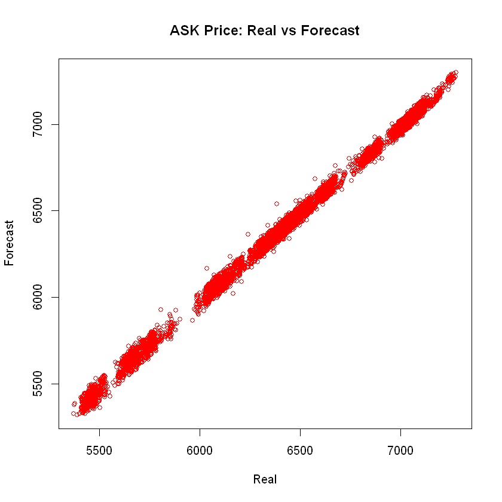

```r
a_ask <- forecast_result_ask$forecast_ask  # forecast data
b_ask <- forecast_result_ask$actual_ask    # real data
plot(b_ask, a_ask, col="red", main = "ASK Price: Real vs Forecast", pch = 1, cex = 0.9, type ="p", xlab = "Real", ylab="Forecast")
```

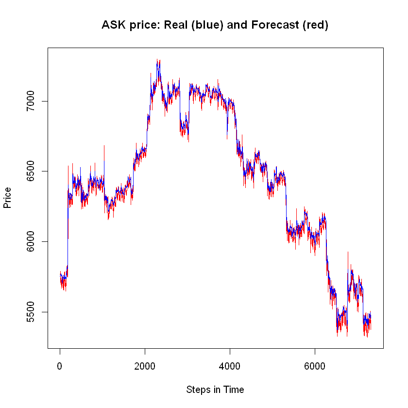

```r
# ----- Всички данни от тестовата последователност за цена "Продава" - Реални и Прогнозни -----
matplot(a_ask, xlab="Steps in Time",ylab="Price",type = c("l"), col="red" , main = "ASK price: Real (blue) and Forecast (red)") # forecast data
matlines(b_ask, type = c("l"), col="blue") # real data
```

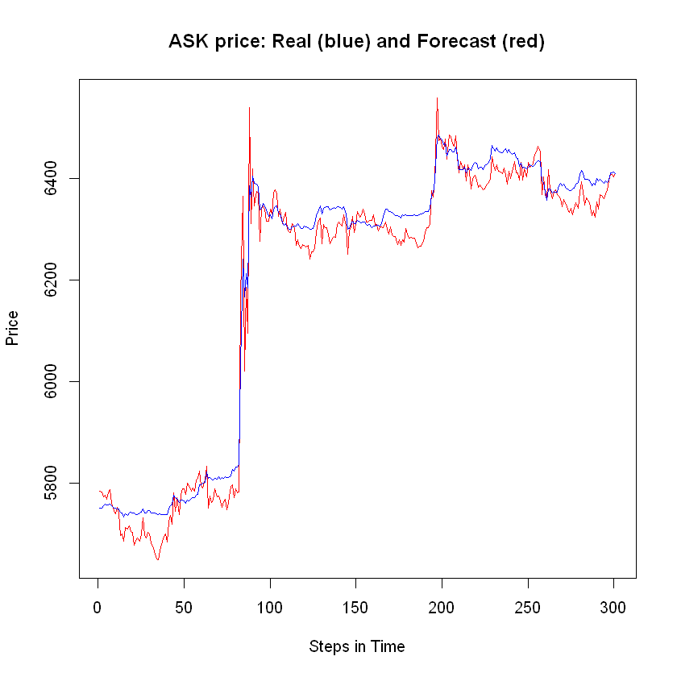

```r
# ----- Наблюдения от 100 до 400 от тестовата последователност за цена "Продава" - Реални и Прогнозни -----
matplot(a_ask[100:400], xlab="Steps in Time",ylab="Price",type = c("l"), col="red", main = "ASK price: Real (blue) and Forecast (red)") #forecast data
matlines(b_ask[100:400], type = c("l"), col="blue") #actual data
```

Резултати и графика от прогнозата за цена "купува"

```r
# ----- първите 5 наблюдения от тестовата последователност за цена "купува": сравнение между прогноза и реални данни -----
head(forecast_result_bid)
```

|  | forecast_bid | actual_bid |
| --- | --- | --- |
| 7321 | 5707.362 | 5735.16 |
| 7322 | 5696.760 | 5736.95 |
| 7323 | 5703.325 | 5736.98 |
| 7324 | 5714.572 | 5736.99 |
| 7325 | 5706.712 | 5741.36 |
| 7326 | 5705.175 | 5743.92 |

```r
# ----- последните 5 наблюдения от тестовата последователност за цена "Купува": сравнение между прогноза и реални данни -----
tail(forecast_result_bid)
```

|  | forecast_bid | actual_bid |
| --- | --- | --- |
| 14634 | 5309.542 | 5400.00 |
| 14635 | 5322.176 | 5400.00 |
| 14636 | 5320.662 | 5387.67 |
| 14637 | 5296.957 | 5384.99 |
| 14638 | 5327.599 | 5399.95 |
| 14639 | 5323.248 | 5399.95 |

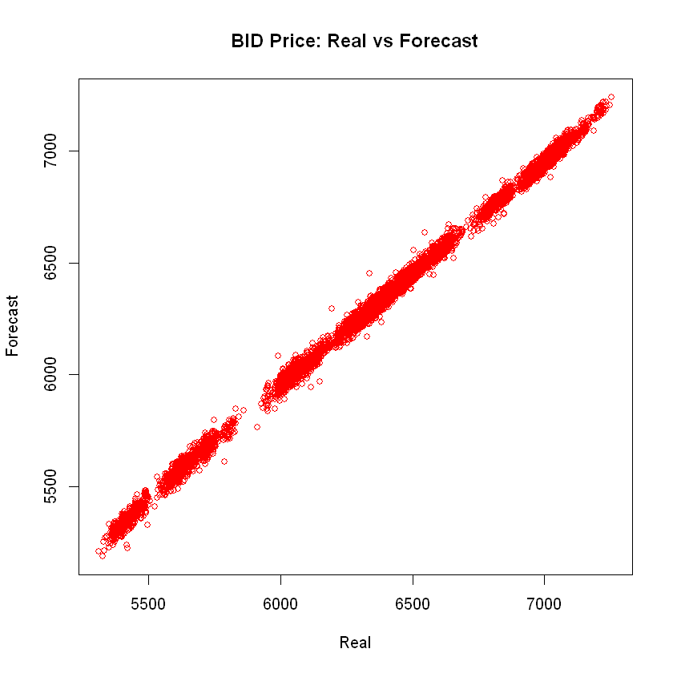

```r
a_bid <- forecast_result_bid$forecast_bid  # forecast data
b_bid <- forecast_result_bid$actual_bid    # real data
plot(b_bid, a_bid, col="red", main = "BID Price: Real vs Forecast", pch = 1, cex = 0.9, type ="p", xlab = "Real", ylab="Forecast")
```

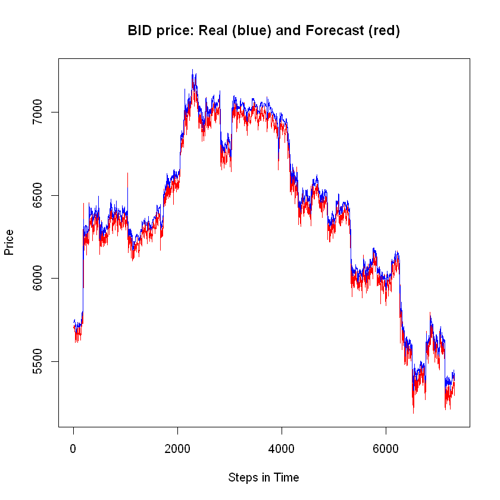

```r
# ----- Всички данни от тестовата последователност за цена "Купува" - Реални и Прогнозни -----
matplot(a_bid, xlab="Steps in Time",ylab="Price",type = c("l"), col="red", main = "BID price: Real (blue) and Forecast (red)") # forecast data
matlines(b_bid, type = c("l"), col="blue") # actual data
```

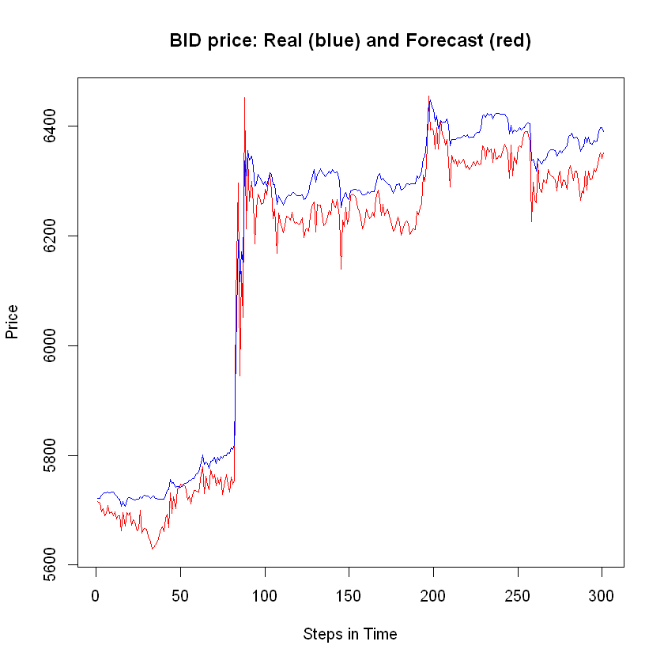

```r
# ----- Наблюдения от 100 до 400 от тестовата последователност за цена "Купува" - Реални и Прогнозни -----
matplot(a_bid[100:400], xlab="Steps in Time",ylab="Price",type = c("l"), col="red", main = "BID price: Real (blue) and Forecast (red)") # forecast data)
matlines(b_bid[100:400], type = c("l"), col="blue") # actual data
```

На следващите две графики са предсвтавени едновременно реални и прогнозни данни за цени "купува" и "продава

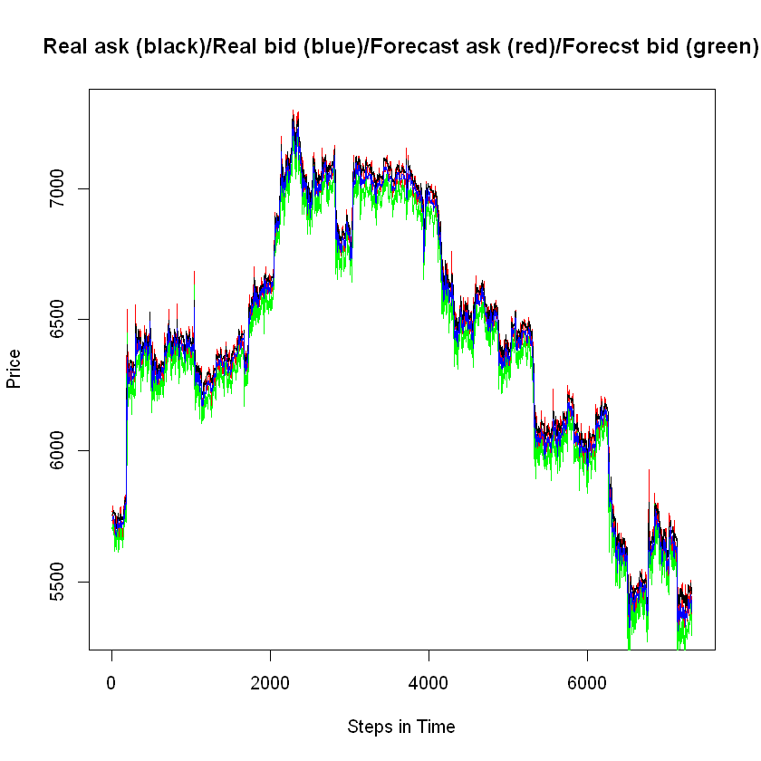

```r
# ----- всички наблюдения от тестовата последователност -----
matplot(a_ask, xlab="Steps in Time",ylab="Price",type = c("l"), col="red", main = "Real ask (black)/Real bid (blue)/Forecast ask (red)/Forecst bid (green)") #forecast ask
matlines(a_bid, type = c("l"), col="green") # forecast bid
matlines(b_ask, type = c("l"), col="black")  #actual ask
matlines(b_bid, type = c("l"), col="blue") #actual ask
```

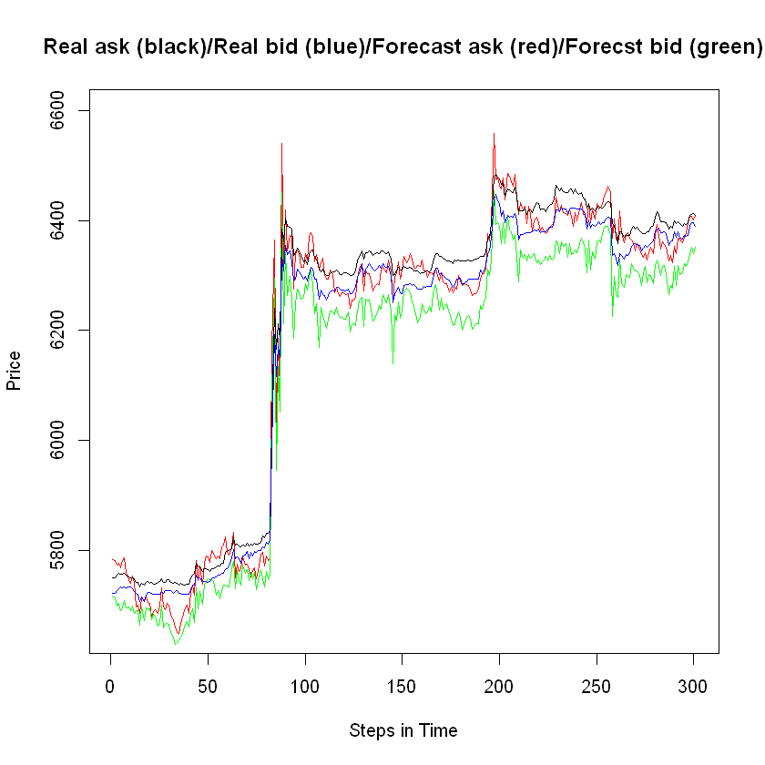

```r
# ----- първите 50 наблюдения от тестовата последователност -----
matplot(a_ask[100:400], xlab="Steps in Time",ylab="Price",type = c("l"), col="red", ylim=c(5650,6600), main = "Real ask (black)/Real bid (blue)/Forecast ask (red)/Forecst bid (green)") #forecast ask
matlines(a_bid[100:400], type = c("l"), col="green") #forecast bid
matlines(b_ask[100:400], type = c("l"), col="black")  #actual ask
matlines(b_bid[100:400], type = c("l"), col="blue" ) #actual bid
```

```r
# ----- Изчисляване на Mean absolute percentage error (средна абсолютна процентна грешка) за цвете цени - купува и продава ----
MAPE_ask=sum(abs((b_ask-a_ask)/b_ask))/nrow(test_data_ask)
MAPE_bid=sum(abs((b_bid-a_bid)/b_bid))/nrow(test_data_bid)
```

### Заключение

В настоящата разработка е показан подход за прогнозиране чрез на цена "Продава" (ask price) и цена "Купува" (bid price) чрез използване на дълбочината на пазара. Този подход е по-рядко използван, тъй като повечето модели се тестват с фактически цени, а не с офертни. Използвани са вътрешнодневни данни (база 5 минути) за цените на криптовалута Bitcoin за период 2018-06-21 20:00:00 до 2018-08-11 15:25:00.

Прогнозата е изградена с невронна мрежа с обратно разпространение. За всеки обучаващ пример се извършват т. нар. прав пас (разпространение на активационните стойности) и обратен пас (анализ на грешките на изхода и разпространение на корекциите на теглата на връзките между елементите от различните слоеве.

#### Обобщение на използваната невронна мрежа:

- Използваната невронна мрежа е с 2 скрити слоя - първият, от които е с 4 неврона, вторият е с 2 неврона.
- Входните параметри са 100 на брой - 50 цени за поръчки "покупка" и 50 цени за поръчки "Продажба"
- Изходите са два - прогноза за цена "Продава" и цена "Купува" в следващия период.
- Използваната формула за невронната мрежа е:

$ \begin{aligned} \large F= {ask.price_n}_{t+1} + {bid.price_1}_{t+1} \sim {ask.price_1}_{t} + {ask.price_2}_{t}+...+{ask.price_n}_{t}+{bid.price_1}_{t}+{bid.price_2}_{t}+...+{bid.price_n}_{t} \end{aligned} $

*(формулата е по-подробно описана по-горе в изложението)*

- Използвана е логистична активационна функция :  
  $ \begin{aligned} \large f(x) = \frac{1}{1 + e^{-x}} \end{aligned} $
- Мрежата не успя да се обучи за стандартния максимален брой стъпки за обучение (100,000) и е сменен на 300,000 стъпки
- Използван алгоритъм rprop+ (гъвкав Алгоритъм с обратно разпространение). Обратно разпространение на грешката е градиентен оптимизационен метод целящ намаляването на грешката която мрежата допуска в изходния слой.
- Използваната функция за изчисляване на грешката по време на обучението на невронната мрежа е SSE(sum of squared errors) $ \begin{aligned} \large SSE=\sum_{i=1}^n (y_i - \hat{y_i})^2 \end{aligned} $

При прогнозирането на времеви редове се определя стойност за наблюдаваната величина в бъдещи моменти от времето. В общия случай не съществува единствено решение което да гарантира абсолютна точност на прогнозата. Стойностите на теглата в изкуствената невронна мрежа се определят с помощта на точни оптимизационни числени методи или вероятностни (евристични) числени методи.

За измерване на допуснатата грешка е изчислена средна абсолютна процентна грешка или MAPE(Mean Absolute Percentage Error)

$ \begin{aligned} \large MAPE=\sum_{t=1}^n \left\lvert { \frac{Y_t-F_t}{Y_t} } \right\rvert \frac{100\%}{n} \end{aligned} $

Средната абсолютна процентна грешка представлява средна аритметична от абсолютните стойности на грешките на отделните прогнози, отнесени в процент към действителния размер на прогнозираното явление. Прогнозите със средна абсолютна процентна грешкка под 10% се класифицират с висока точност. По-малките стойности показват по-добро прилягане на прогнозата към реалните данни.

```r
paste("MAPE_ask = ", round(MAPE_ask*100,2), "%", sep="")
paste("MAPE_bid = ", round(MAPE_bid*100,2), "%", sep="")
```

'MAPE_ask = 0.46%'

'MAPE_bid = 0.82%'

От горепосечните графики в по-едър мащаб може да се види, че прогнозата е по-чувствителна от реалните данни. Това може да се дължи на факта, че се прогнозира най-високата цена "Продава" и най-ниската цена "Купува" чрез данни от периферията на поръчките за покупка(нагоре от bid) и продажба (надолу от ask).

Тази преоразмереност на прогнозата може е породена различни причини, на база изследването до тук най-вероятната причина е серийна корелация на входните данни - всички входни променливи променят стойностите си по едно и също време

За да се избегне лекото израждане(свръхчувствителността) на прогнозата като следваща стъпка от изследването могат да се добавят нови променливи, които сумират общоя обем на търсенето и предлагането и общия брой поръчки има съответно.

Друга посока за последващо изследване би било прогнозиране чрез с по-сложна невронна мрежа, с по-сложна архитектура. Може да се експериментира с различни варианти - повече скрити слоеве и повече неврони в тях.